# Exploring the BRFSS data

## Setup

### Load packages

```r
library(ggplot2)
library(dplyr)
library(RColorBrewer)
```

### Load data

Make sure your data and R Markdown files are in the same directory. When loaded your data file will be called `brfss2013`. Delete this note when before you submit your work.

```r
load("brfss2013.RData")
```

## Part 1: Data

The data was collected from adult U.S. residents using stratified sample. It might exist bias such as conveniece bias, Non-response bias and voluntary bias during data collecting.

Generalizability: Population of interest are the US adult residents at households. The analysis can be generalized to the population as it is an observational study using RANDOM SAMPLING.

Causality: As BRFSS is just an observation study, there is no causation that can be established for any pair of variables. There is NO RANDOM ASSIGNMENT.

## Part 2: Research questions

**Research quesion 1:** The general health status of the people who participated BRFSS 2013.

**Research quesion 2:** Is sleep time related to general health status and high blood pressure?

**Research quesion 3:** Is veterian rates of men and women exist difference? What is the distribution of general health status of people who are veterian or not? * * *

## Part 3: Exploratory data analysis

### Research quesion 1

The table and plot show the general distribution of general health status according the data from BRFSS2013.

Conclusion: We can see that most people’s general health status are at “Very good” or “Good”.

```r
counts_genhlth <- table(brfss2013$genhlth)
counts_genhlth
```

```
##
## Excellent Very good      Good      Fair      Poor
##     85482    159076    150555     66726     27951
```

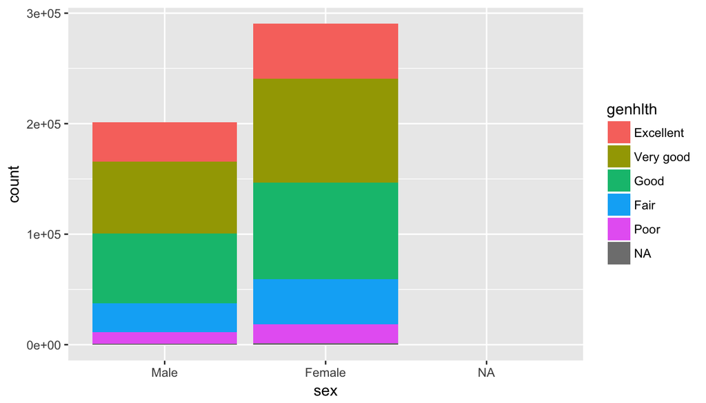

```r
brfss2013$genhlth <- as.factor(brfss2013$genhlth)
brfss2013$sex <- as.factor(brfss2013$sex)
ggplot(brfss2013, aes(x=sex, fill = genhlth)) +
    geom_bar()
```

Conclusion: We can see that most people’s general health status are at “Very good” or “Good”.

### Research quesion 2

First, I classify the data into two groups by bphigh4 (if one had been told boold pressure high). Then I draw two tables and two plots to show the mean sleep time of people in different health status grouping by bphigh4.

Conclusion: It seems that the more sleep time one has, the healthier one is. Besides, it seems that in the group of no bad health status (including “excellent”, “very good”, “good” and “fair”), the people who have ever been told high blood pressure sleep more time than those who never been told high blood pressure.

```r
bp_high <- brfss2013 %>%
    filter(bphigh4 == "Yes")
bp_nevhigh <- brfss2013 %>%
    filter(bphigh4 == "No")

bp_high %>%
    group_by(genhlth) %>%
    summarise(mean_sleptim = mean(sleptim1,na.rm=TRUE), sd_sleptim = sd(sleptim1,na.rm=TRUE), n = n())
```

```
## # A tibble: 6 × 4
##     genhlth mean_sleptim sd_sleptim     n
##      <fctr>        <dbl>      <dbl> <int>
## 1 Excellent     7.254889   1.308905 15834
## 2 Very good     7.169312   1.248219 52264
## 3      Good     7.082727   1.466603 70383
## 4      Fair     6.937992   1.814717 40713
## 5      Poor     6.731529   2.353377 18750
## 6        NA     7.144342   1.900702   977
```

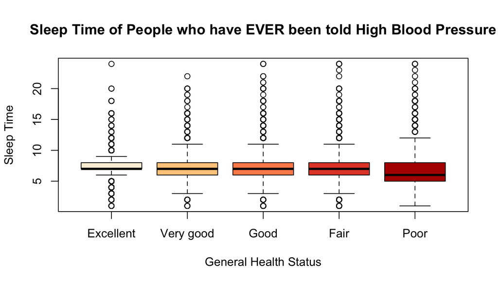

```r
    boxplot(sleptim1 ~ genhlth, data=bp_high,
            main = "Sleep Time of People who have EVER been told High Blood Pressure",
            xlab = "General Health Status",
            ylab = "Sleep Time",
            col=brewer.pal(5,"OrRd"))
```

```r
bp_nevhigh %>%
    group_by(genhlth) %>%
    summarise(mean_sleptim = mean(sleptim1,na.rm=TRUE), sd_sleptim = sd(sleptim1,na.rm=TRUE), n = n())
```

```
## # A tibble: 6 × 4
##     genhlth mean_sleptim sd_sleptim      n
##      <fctr>        <dbl>      <dbl>  <int>
## 1 Excellent     7.175528   1.191673  68138
## 2 Very good     7.073134   1.185151 103213
## 3      Good     7.001504   1.421424  76799
## 4      Fair     6.833237   1.803527  24799
## 5      Poor     6.752217   2.457264   8799
## 6        NA     7.211316   1.704916    939
```

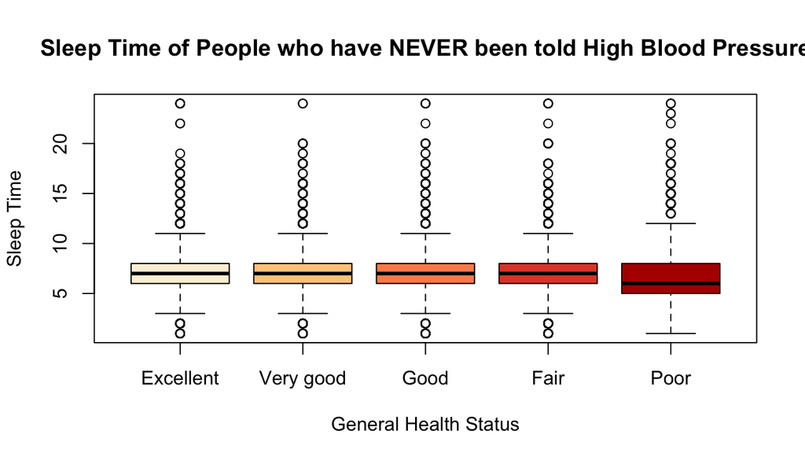

```r
    boxplot(sleptim1 ~ genhlth, data=bp_nevhigh,
            main = "Sleep Time of People who have NEVER been told High Blood Pressure",
            xlab = "General Health Status",
            ylab = "Sleep Time",
            col=brewer.pal(5,"OrRd"))
```

Conclusion: It seems that the more sleep time one has, the healthier one is. Besides, it seems that in the group of no bad health status (including “excellent”, “very good”, “good” and “fair”), the people who have ever been told high blood pressure sleep more time than those who never been told high blood pressure.

### Research quesion 3

First, I classify the data into two groups by sex. Then I draw two tables and two plots to show the people counts of different health status who are veterian or not grouping by sex.

```r
male <- brfss2013 %>%
    filter(sex == "Male")
female <- brfss2013 %>%
    filter(sex == "Female")

male_genhlth_vet <- table(male$genhlth, male$veteran3)
male_genhlth_vet
```

```
##
##               Yes    No
##   Excellent  8362 27296
##   Very good 16695 48336
##   Good      18257 44589
##   Fair       8592 17237
##   Poor       3775  6904
```

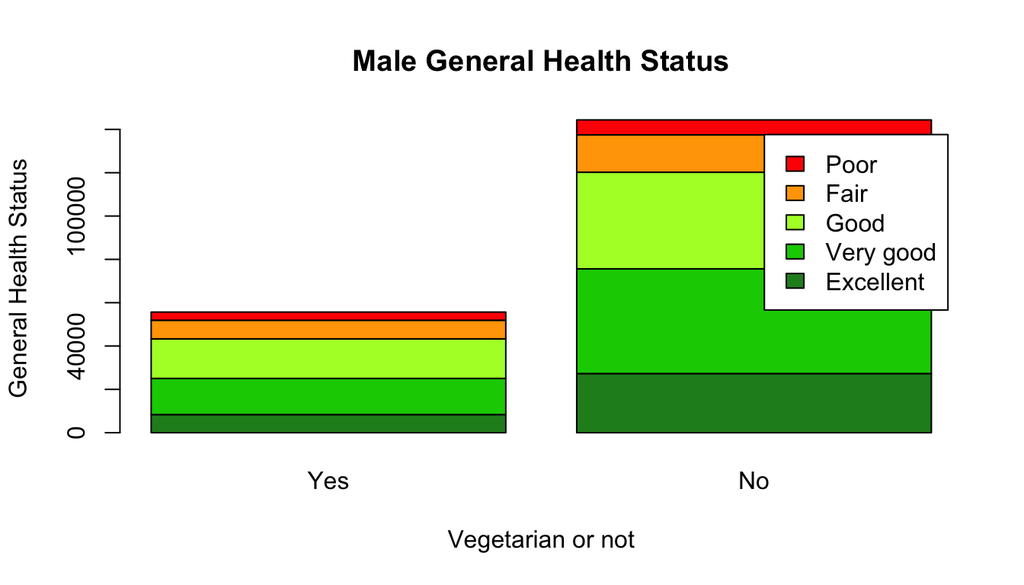

```r
barplot(male_genhlth_vet,
        main = "Male General Health Status",
        xlab = "Vegetarian or not", ylab = "General Health Status",
        col = c("forestgreen","green3","greenyellow","orange","red"),
        legend = rownames(male_genhlth_vet))
```

```r
female_genhlth_vet <- table(female$genhlth, female$veteran3)
female_genhlth_vet
```

```
##
##               Yes    No
##   Excellent   983 48708
##   Very good  1848 92011
##   Good       1631 85819
##   Fair        742 40060
##   Poor        290 16929
```

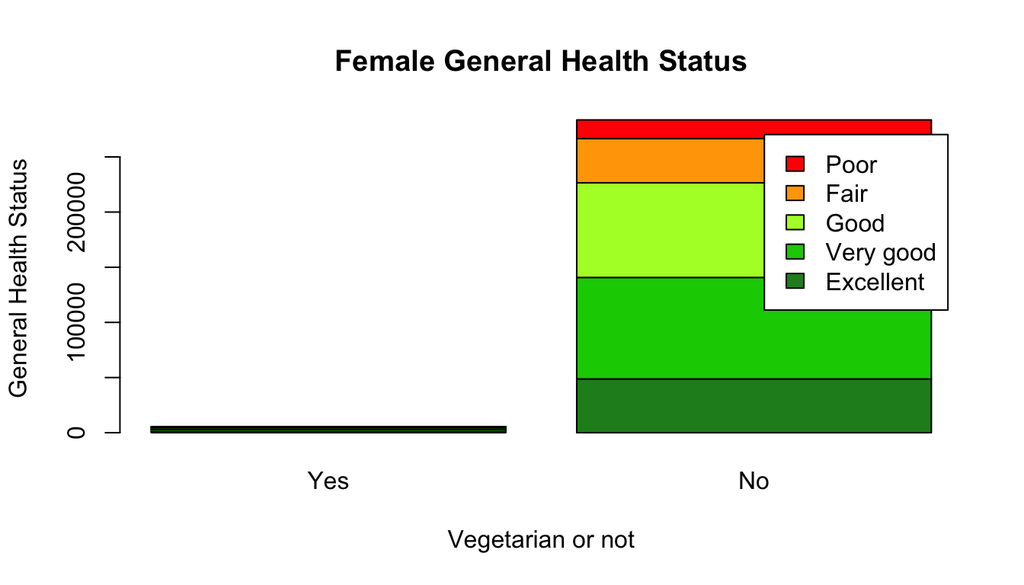

```r
barplot(female_genhlth_vet,
        main = "Female General Health Status",
        xlab = "Vegetarian or not", ylab = "General Health Status",
        col = c("forestgreen","green3","greenyellow","orange","red"),
        legend = rownames(female_genhlth_vet))
```

Conclosion: The veterian rate of male is higher than female. I can’t see the significance difference of general health status between veterian group and non-veterian group.